# 140.651 - Lab 2

### R markdown = R code + Markdown

#### Markdown

- Markdown is a text-to-HTML conversion tool
- Markdown allows you to write using an easy to read/write plain text format, then convert it to structurally valid HTML (or PDF, Word) file.
  - The Markdown text format allows to insert bullet points, numbered lists, text in bold/italics, URL links etc.
- To create Markdown file, in RStudio: clikc `File > New file... > R script/Text file` and save that file with extension `.md`
- To compile Markdown file into HTML file (default) or other (PDF, Word): click `Preview` tab in RStudio
- Example:

[figure not shown]

#### R Markdown

- R Markdown is a file format that allows to mix text written in Markdown with `R` code chunks
- R code chunks contain actual `R` code which gets executed when we compile the R Markdown file
  - The output of the `R` code execution (numbers, tables, plots…) is displayed in the output document by default
  - The `R` code itself is also displayed in the output document by default (can be hidden)
- To create R Markdown file in RStudio, we need to have `rmarkdown` R package installed:

  ```r
  install.packages("rmarkdown")
  ```

  Then click `File > New File > R Markdown...`;
- To compile R Markdown file into HTML file (default) or other (PDF, Word) into HTML document: click `Knit` tab in RStudio (again, note knit output options)

[figure not shown]

- To change output file to PDF:

[figure not shown]

[figure not shown]

#### Resources

- [Creating RMarkdown Documents in RStudio](http://jtleek.com/advdatasci/slides/03-rmarkdown-and-github.html#3)
- [Markdown Cheatsheet](https://github.com/adam-p/markdown-here/wiki/Markdown-Cheatsheet)

### HW1 - Problem 12

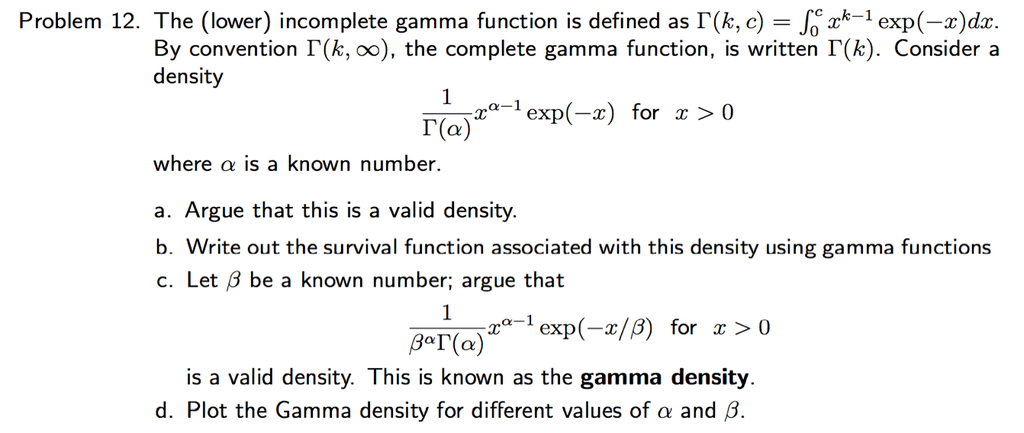

- 1. A valid density $f(x)$ should satisfy two conditions: 1). $f(x)\geq 0$ for all $x$. 2). $\int_{-\infty}^{\infty}f(x)dx=1$. [*Reference: Lecture 2, slide 26/43 - “PDF”*]
  - $f(x)=\frac{1}{\Gamma(\alpha)}x^{\alpha-1}\exp(-x)\geq 0$ for $x>0$.
  - $\int_{-\infty}^{\infty}f(x)dx=\frac{1}{\Gamma(\alpha)}\int_0^{\infty}x^{\alpha-1}\exp(-x)=\frac{1}{\Gamma(\alpha)}\Gamma(\alpha)=1$.
- 2. $S(t)=1-F(t)$. Integrate the density from 0 to $t$ to compute $F(t)$: $F(t) = \int_{-\infty}^tf(x)dx.$
- 3. This function is greater than 0. To show that it integrates to 1, we use the change of variable formula $y=x/\beta$:
  - $\int_0^{\infty}\frac{1}{\beta^{\alpha}\Gamma(\alpha)}x^{\alpha-1}\exp(-x/\beta)=\frac{1}{\beta^{\alpha}\Gamma(\alpha)}\int_0^{\infty}(\beta y)^{\alpha-1}\exp(-y)\beta dy=1$.
- 4. The `dgamma()` function returns the density of gamma distribution.

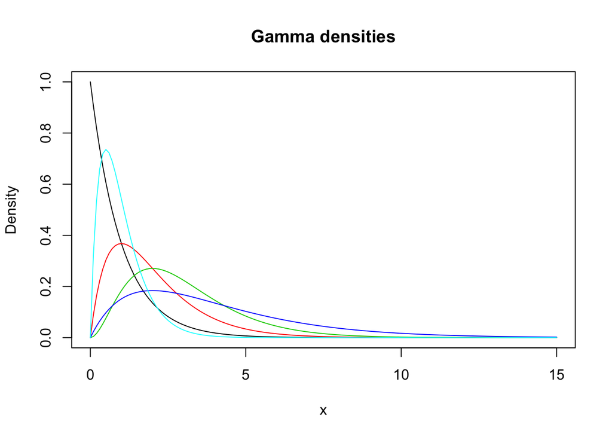

```r
x = seq(0,15,0.1)
plot(x,dgamma(x,shape=1,scale=1), main = "Gamma densities", xlab = "x", ylab = "Density", type = "l")
lines(x,dgamma(x,shape=2,scale=1), col=2)
lines(x,dgamma(x,shape=3,scale=1), col=3)
lines(x,dgamma(x,shape=2,scale=2), col=4)
lines(x,dgamma(x,shape=2,scale=0.5), col=5)
```

### HW1 - Problem 13

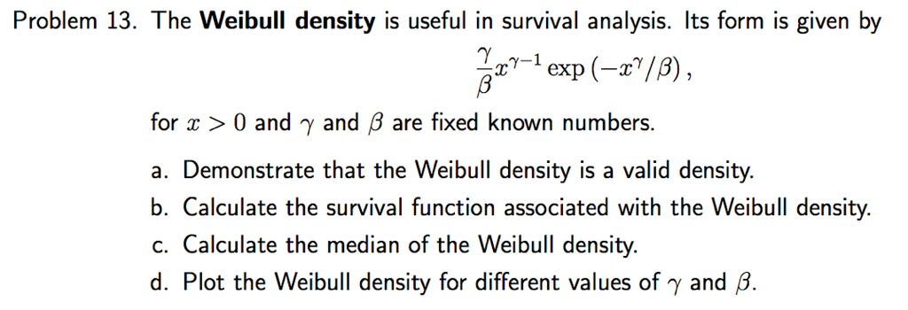

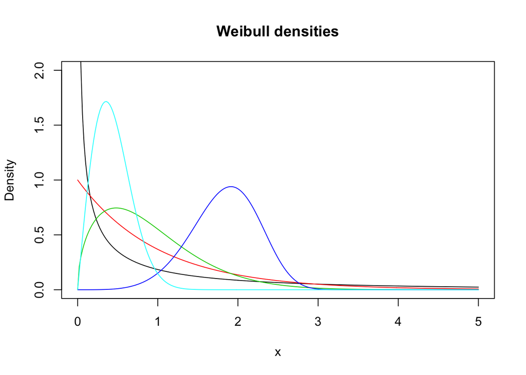

```r
x = seq(0,5,0.02)
plot(x,dweibull(x,shape=0.5,scale=1), main = "Weibull densities", xlab = "x", ylab = "Density", type = "l",ylim=c(0,2))
lines(x,dweibull(x,shape=1,scale=1), col=2)
lines(x,dweibull(x,shape=1.5,scale=1), col=3)
lines(x,dweibull(x,shape=5,scale=2), col=4)
lines(x,dweibull(x,shape=2,scale=0.5), col=5)
```

The same plot can be made using `curve()` function.

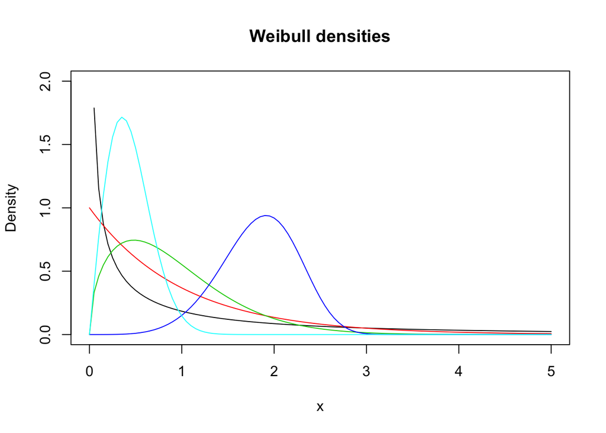

```r
x = seq(0,5,0.02)
curve(dweibull(x,shape=0.5,scale=1), from=0, to=5, main = "Weibull densities", xlab = "x", ylab = "Density", type = "l",ylim=c(0,2))
curve(dweibull(x,shape=1,scale=1), col=2, add=TRUE)
curve(dweibull(x,shape=1.5,scale=1), col=3, add=TRUE)
curve(dweibull(x,shape=5,scale=2), col=4, add=TRUE)
curve(dweibull(x,shape=2,scale=0.5), col=5, add=TRUE)
```

### HW1 - Problem 6

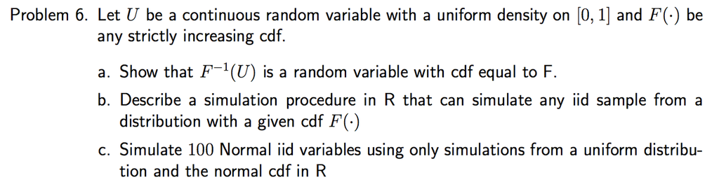

- 1. Let $X=F^{-1}(U)$. Since $F(\cdot)$ is strictly increasing, it is invertible and $F^{-1}(\cdot)$ is also strictly increasing. The CDF of $X$ is
     $$F_X(x)=Pr(X\leq x)=Pr(F^{-1}(U)\leq x).$$
     Since $F(\cdot)$ and $F^{-1}(\cdot)$ are both strictly increasing, the event $\{F^{-1}(U)\leq x\}$ is equivalent to the event $\{U\leq F(x)\}$. Therefore
     $$Pr(F^{-1}(U)\leq x)=Pr(U \leq F(x)).$$
     Integrating the density of $U$ we have
     $$Pr(U \leq F(x))=\int_{0}^{F(x)} 1du=F(x).$$
     Hence $F^{-1}(U)$ has distribution function $F(\cdot)$.
- 2. First simulate an iid sample $\{U_i\}_{i=1,2,...n}$ from Uniform[0,1] using function `runif()`. Then apply transformation $X_i=F^{-1}(U_i)$. $X_i$ have cdf $F(\cdot)$.
- 3. Simulate uniform random variables and apply the normal quantile function to obtain normal variables.
  - Note: `qqnorm()` function produces a normal Q-Q plot. That is, it compares sample quantiles from provided vector of values aganist theoretical $N(0,1)$ quantiles values. `qqline()` function adds a line $y=x$. If the provided vector of values comes from distribution similar to $N(0,1)$, then the points in the Q–Q plot will approximately lie on the line $y=x$.

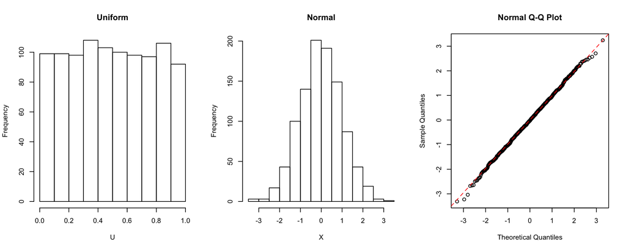

```r
# Simulate 1000 variables to better view the distribution.
set.seed(123)
U = runif(1000, min=0, max=1)
X = qnorm(U)
par(mfrow=c(1,3))
hist(U, main="Uniform")
hist(X, main="Normal")

# Compare distribution of generated X vector aganist normal distribution
qqnorm(X)
qqline(X, col=2, lty=2)
```

To simulate from other distributions, generate uniform R.Vs and apply corresponding quantile functions (`qexp()` for exponential, `qgamma()` for gamma distribution,…).